# vail_causal

## Vail Causal Inference Project

### Step 1: Project Design

**Goal**: Estimate the causal effect of Vail Resorts purchasing/managing a ski resort on a town’s economy (e.g., housing prices, employment, wages, or tourism spending).

**Treatment**: Year when Vail Resorts acquired a ski resort in that town.  
**Control group**: Similar towns with ski resorts that Vail did not acquire.  
**Method**: Difference-in-Differences (DiD) or Synthetic Control.

**Data sources**:

- Vail Resorts acquisitions list (10-K, news)
- Economic indicators (U.S. Census ACS)

### Step 2: Pull and Format Census Data

Insert your specific API key here that the Census email's when you sign up for a API key.

```python
import pandas as pd
import numpy as np
import requests
from time import sleep
import matplotlib.pyplot as plt
import seaborn as sns
from sklearn.preprocessing import StandardScaler
from sklearn.metrics import euclidean_distances
import warnings
warnings.filterwarnings('ignore')

# Your API key
API_KEY = ""
```

```python
# Focus on major US acquisitions with good data
vail_acquisitions_post_2011 = [
    {"resort": "Northstar California Resort", "town": "Truckee", "state": "CA", "state_fips": "06",
     "county": "Nevada", "county_fips": "057", "acquisition_year": 2010, "note": "Close to cutoff"},
    {"resort": "Kirkwood Mountain Resort", "town": "Kirkwood", "state": "CA", "state_fips": "06",
     "county": "Alpine", "county_fips": "003", "acquisition_year": 2012},
    {"resort": "Park City Mountain Resort", "town": "Park City", "state": "UT", "state_fips": "49",
     "county": "Summit", "county_fips": "043", "acquisition_year": 2014},
    {"resort": "Whistler Blackcomb", "town": "Whistler", "state": "BC", "country": "Canada",
     "acquisition_year": 2016, "note": "International"},
    {"resort": "Stowe Mountain Resort", "town": "Stowe", "state": "VT", "state_fips": "50",
     "county": "Lamoille", "county_fips": "015", "acquisition_year": 2017},
    {"resort": "Crested Butte Mountain Resort", "town": "Crested Butte", "state": "CO", "state_fips": "08",
     "county": "Gunnison", "county_fips": "051", "acquisition_year": 2018},
    {"resort": "Stevens Pass", "town": "Skykomish", "state": "WA", "state_fips": "53",
     "county": "Chelan", "county_fips": "007", "acquisition_year": 2018},
    {"resort": "Okemo Mountain Resort", "town": "Ludlow", "state": "VT", "state_fips": "50",
     "county": "Windsor", "county_fips": "027", "acquisition_year": 2018},
    {"resort": "Mount Sunapee Resort", "town": "Newbury", "state": "NH", "state_fips": "33",
     "county": "Merrimack", "county_fips": "013", "acquisition_year": 2018},
]

# Filter to US only and post-2011
us_vail_acquisitions = [
    resort for resort in vail_acquisitions_post_2011
    if 'state_fips' in resort and resort['acquisition_year'] >= 2012
]

print(f"Focusing on {len(us_vail_acquisitions)} US Vail acquisitions after 2011:")
for resort in us_vail_acquisitions:
    print(f"  {resort['town']}, {resort['state']} ({resort['acquisition_year']})")
```

```
Focusing on 7 US Vail acquisitions after 2011:
  Kirkwood, CA (2012)
  Park City, UT (2014)
  Stowe, VT (2017)
  Crested Butte, CO (2018)
  Skykomish, WA (2018)
  Ludlow, VT (2018)
  Newbury, NH (2018)
```

```python
# Define major Ikon Pass/Alterra resorts to EXCLUDE!!!
# Based on Alterra ownership and major Ikon partnerships
ikon_alterra_resorts = [
    'Aspen', 'Snowmass',  # Aspen Skiing Company (Ikon partner)
    'Jackson',  # Jackson Hole (Ikon partner)
    'Steamboat Springs',  # Steamboat (Alterra-owned)
    'Winter Park',  # Winter Park (Alterra-owned)
    'Copper Mountain',  # Copper (Alterra-owned)
    'Eldora',  # Eldora (Alterra-owned)
    'Solitude',  # Solitude (Alterra-owned)
    'Deer Valley',  # Deer Valley (Alterra-owned)
    'Alta',  # Alta (major Ikon partner)
    'Snowbird',  # Snowbird (major Ikon partner)
    'Big Sky',  # Big Sky (Alterra-owned)
    'Palisades Tahoe', 'Squaw Valley', 'Alpine Meadows',  # Palisades Tahoe (Alterra-owned)
    'Mammoth',  # Mammoth (Alterra-owned)
    'June Mountain',  # June Mountain (Alterra-owned)
    'Killington',  # Killington (Alterra-owned)
    'Stratton',  # Stratton (Alterra-owned)
    'Tremblant',  # Tremblant (Alterra-owned)
    'Blue Mountain',  # Blue Mountain (Alterra-owned)
    'Crystal Mountain',  # Crystal Mountain (Alterra-owned)
]
```

```python
# Define truly independent ski resort towns (not Vail, not Ikon/Alterra)
independent_ski_towns = [
    # Colorado - truly independent
    {"town": "Telluride", "state": "CO", "state_fips": "08", "county": "San Miguel", "county_fips": "113"},
    {"town": "Loveland", "state": "CO", "state_fips": "08", "county": "Clear Creek", "county_fips": "019"},
    {"town": "Wolf Creek", "state": "CO", "state_fips": "08", "county": "Mineral", "county_fips": "079"},
    {"town": "Monarch", "state": "CO", "state_fips": "08", "county": "Chaffee", "county_fips": "015"},
    {"town": "Silverton", "state": "CO", "state_fips": "08", "county": "San Juan", "county_fips": "111"},

    # Idaho - independent
    {"town": "Sun Valley", "state": "ID", "state_fips": "16", "county": "Blaine", "county_fips": "013"},
    {"town": "McCall", "state": "ID", "state_fips": "16", "county": "Valley", "county_fips": "085"},
    {"town": "Ketchum", "state": "ID", "state_fips": "16", "county": "Blaine", "county_fips": "013"},

    # Montana - independent
    {"town": "Whitefish", "state": "MT", "state_fips": "30", "county": "Flathead", "county_fips": "029"},
    {"town": "Red Lodge", "state": "MT", "state_fips": "30", "county": "Carbon", "county_fips": "009"},
    {"town": "Bridger Bowl", "state": "MT", "state_fips": "30", "county": "Gallatin", "county_fips": "031"},

    # Utah - independent (excluding Alterra/Ikon)
    {"town": "Brighton", "state": "UT", "state_fips": "49", "county": "Salt Lake", "county_fips": "035"},
    {"town": "Powder Mountain", "state": "UT", "state_fips": "49", "county": "Weber", "county_fips": "057"},
    {"town": "Nordic Valley", "state": "UT", "state_fips": "49", "county": "Weber", "county_fips": "057"},

    # California - independent
    {"town": "China Peak", "state": "CA", "state_fips": "06", "county": "Fresno", "county_fips": "019"},
    {"town": "Mount Shasta", "state": "CA", "state_fips": "06", "county": "Siskiyou", "county_fips": "093"},
    {"town": "Dodge Ridge", "state": "CA", "state_fips": "06", "county": "Tuolumne", "county_fips": "109"},

    # Vermont - independent (excluding Alterra)
    {"town": "Mad River Glen", "state": "VT", "state_fips": "50", "county": "Washington", "county_fips": "023"},
    {"town": "Burke", "state": "VT", "state_fips": "50", "county": "Caledonia", "county_fips": "005"},
    {"town": "Jay Peak", "state": "VT", "state_fips": "50", "county": "Orleans", "county_fips": "019"},
    {"town": "Bolton Valley", "state": "VT", "state_fips": "50", "county": "Chittenden", "county_fips": "007"},

    # New Hampshire - independent
    {"town": "Cannon Mountain", "state": "NH", "state_fips": "33", "county": "Grafton", "county_fips": "009"},
    {"town": "Waterville Valley", "state": "NH", "state_fips": "33", "county": "Grafton", "county_fips": "009"},
    {"town": "Bretton Woods", "state": "NH", "state_fips": "33", "county": "Coos", "county_fips": "007"},

    # Washington - independent
    {"town": "Mount Baker", "state": "WA", "state_fips": "53", "county": "Whatcom", "county_fips": "073"},
    {"town": "White Pass", "state": "WA", "state_fips": "53", "county": "Lewis", "county_fips": "041"},
    {"town": "49 Degrees North", "state": "WA", "state_fips": "53", "county": "Stevens", "county_fips": "065"},

    # Oregon - independent
    {"town": "Mount Hood Skibowl", "state": "OR", "state_fips": "41", "county": "Clackamas", "county_fips": "005"},
    {"town": "Mount Bachelor", "state": "OR", "state_fips": "41", "county": "Deschutes", "county_fips": "017"},
    {"town": "Anthony Lakes", "state": "OR", "state_fips": "41", "county": "Union", "county_fips": "061"},

    # New York - independent
    {"town": "Lake Placid", "state": "NY", "state_fips": "36", "county": "Essex", "county_fips": "031"},
    {"town": "Gore Mountain", "state": "NY", "state_fips": "36", "county": "Warren", "county_fips": "113"},

    # Pennsylvania - independent
    {"town": "Blue Knob", "state": "PA", "state_fips": "42", "county": "Bedford", "county_fips": "009"},

    # Maine - independent
    {"town": "Sugarloaf", "state": "ME", "state_fips": "23", "county": "Franklin", "county_fips": "007"},
    {"town": "Sunday River", "state": "ME", "state_fips": "23", "county": "Oxford", "county_fips": "017"},
]

print(f"\n{len(independent_ski_towns)} truly independent ski resort towns identified")
print("(Excluding Vail/Epic Pass and Ikon/Alterra resorts)")
```

```
35 truly independent ski resort towns identified
(Excluding Vail/Epic Pass and Ikon/Alterra resorts)
```

```python
# Function to fetch ACS data for a list of towns
def fetch_acs_for_towns(towns_list, variables, years, api_key, label="towns"):
    all_data = []

    for year in years:
        var_str = ','.join(variables)
        print(f"Fetching {label} data for {year}...")

        for town_info in towns_list:
            state, county = town_info['state_fips'], town_info['county_fips']
            town_name = town_info['town']

            url = (f"https://api.census.gov/data/{year}/acs/acs5"
                   f"?get=NAME,{var_str}&for=county:{county}&in=state:{state}&key={api_key}")

            try:
                response = requests.get(url)
                response.raise_for_status()
                data = response.json()

                if len(data) > 1:
                    df = pd.DataFrame(data[1:], columns=data[0])
                    df['year'] = year
                    df['town'] = town_name
                    df['resort_type'] = label
                    all_data.append(df)

            except Exception as e:
                print(f"Failed for {town_name}, {state}-{county}, year {year}: {e}")
            # Be polite to the API
            sleep(0.2)

    if all_data:
        panel_df = pd.concat(all_data, ignore_index=True)

        # Convert numeric variables
        for var in variables:
            panel_df[var] = pd.to_numeric(panel_df[var], errors='coerce')

        return panel_df
    else:
        return pd.DataFrame()
```

#### ACS defines each variable with a specific code, for this example we will use these following variables below:

```python
# Define ACS variables and fetch data
acs_variables = [
    'B01001_001E',  # Total population
    'B01002_001E',  # Median age
    'B25077_001E',  # Median home value
    'B19013_001E',  # Median household income
    'B23025_002E',  # Labor force
    'B23025_004E',  # Employed
    'B25064_001E',  # Median rent
    'B02001_002E',  # White alone
    'B25003_002E',  # Owner occupied units
    'B25003_003E',  # Renter occupied units
]
```

```python
# Focus on 2011-2023 for post-2011 acquisitions
years = [str(y) for y in range(2011, 2024)]

print("Fetching Vail treatment town data...")
treatment_data = fetch_acs_for_towns(us_vail_acquisitions, acs_variables, years, API_KEY, "treatment")

print("Fetching independent control town data...")
control_data = fetch_acs_for_towns(independent_ski_towns, acs_variables, years, API_KEY, "control")
```

```
Fetching Vail treatment town data...
Fetching treatment data for 2011...
Fetching treatment data for 2012...
Fetching treatment data for 2013...
Fetching treatment data for 2014...
Fetching treatment data for 2015...
Fetching treatment data for 2016...
Fetching treatment data for 2017...
Fetching treatment data for 2018...
Fetching treatment data for 2019...
Fetching treatment data for 2020...
Fetching treatment data for 2021...
Fetching treatment data for 2022...
Fetching treatment data for 2023...
Fetching independent control town data...
Fetching control data for 2011...
Fetching control data for 2012...
Fetching control data for 2013...
Fetching control data for 2014...
Fetching control data for 2015...
Fetching control data for 2016...
Fetching control data for 2017...
Fetching control data for 2018...
Fetching control data for 2019...
Fetching control data for 2020...
Fetching control data for 2021...
Fetching control data for 2022...
Fetching control data for 2023...
```

### Step 3: Combine and Clean Data

```python
# Here we will combine and clean the data
if not treatment_data.empty and not control_data.empty:
    # Combine datasets
    all_data = pd.concat([treatment_data, control_data], ignore_index=True)

    # Rename variables
    rename_map = {
        'B01001_001E': 'total_population',
        'B01002_001E': 'median_age',
        'B25077_001E': 'median_home_value',
        'B19013_001E': 'median_household_income',
        'B23025_002E': 'total_labor_force',
        'B23025_004E': 'employed_16_plus',
        'B25064_001E': 'median_rent',
        'B02001_002E': 'white_alone',
        'B25003_002E': 'owner_occupied',
        'B25003_003E': 'renter_occupied'
    }

    all_data = all_data.rename(columns=rename_map)
    all_data['year'] = pd.to_numeric(all_data['year'])

    # Calculate derived variables
    all_data['unemployment_rate'] = ((all_data['total_labor_force'] - all_data['employed_16_plus']) /
                                     all_data['total_labor_force'] * 100)
    all_data['homeownership_rate'] = (all_data['owner_occupied'] /
                                     (all_data['owner_occupied'] + all_data['renter_occupied']) * 100)

    print(f"\n=== DATA SUMMARY ===")
    print(f"Combined dataset shape: {all_data.shape}")
    print(f"Years: {all_data['year'].min()}-{all_data['year'].max()}")
    print(f"Treatment towns: {sorted(all_data[all_data['resort_type']=='treatment']['town'].unique())}")
    print(f"Control towns: {len(all_data[all_data['resort_type']=='control']['town'].unique())} independent resorts")

else:
    print("Error: Could not fetch data")
```

```
=== DATA SUMMARY ===
Combined dataset shape: (546, 18)
Years: 2011-2023
Treatment towns: ['Crested Butte', 'Kirkwood', 'Ludlow', 'Newbury', 'Park City', 'Skykomish', 'Stowe']
Control towns: 35 independent resorts
```

### Step 4: Finding our good controls

#### Below is the matching function that uses multiple criteria, this will find the best control towns using standardized distances

```python
# Matching function with multiple criteria
def find_best_controls_enhanced(treatment_town, acquisition_year, n_controls=5):
    print(f"\n=== Finding Controls for {treatment_town} (acquired {acquisition_year}) ===")

    # Get PRE-treatment data (3 years before acquisition)
    pre_treatment_years = range(max(2011, acquisition_year - 3), acquisition_year)
    print(f"Using pre-treatment years: {list(pre_treatment_years)}")

    # Treatment town data
    treatment_data_pre = all_data[
        (all_data['town'] == treatment_town) &
        (all_data['year'].isin(pre_treatment_years)) &
        (all_data['resort_type'] == 'treatment')
    ].copy()

    if treatment_data_pre.empty:
        print(f"No pre-treatment data for {treatment_town}")
        return [], pd.DataFrame()

    # Control towns data
    control_data_pre = all_data[
        (all_data['year'].isin(pre_treatment_years)) &
        (all_data['resort_type'] == 'control')
    ].copy()

    if control_data_pre.empty:
        print(f"No control data available")
        return [], pd.DataFrame()

    # Calculate average pre-treatment characteristics
    matching_vars = ['total_population', 'median_home_value', 'median_household_income',
                    'unemployment_rate', 'homeownership_rate']

    treatment_chars = treatment_data_pre.groupby('town')[matching_vars].mean()
    if treatment_chars.empty:
        print(f"No treatment characteristics calculated")
        return [], pd.DataFrame()

    treatment_chars = treatment_chars.iloc[0]

    control_chars = control_data_pre.groupby('town')[matching_vars].mean()
    control_chars = control_chars.dropna()

    if control_chars.empty:
        print(f"No valid control characteristics")
        return [], pd.DataFrame()

    print(f"Treatment town characteristics:")
    for var in matching_vars:
        print(f"  {var}: {treatment_chars[var]:,.0f}")

    # Calculate standardized distances
    scaler = StandardScaler()
    all_chars = pd.concat([treatment_chars.to_frame().T, control_chars])
    all_chars_scaled = scaler.fit_transform(all_chars.fillna(0))

    treatment_scaled = all_chars_scaled[0].reshape(1, -1)
    control_scaled = all_chars_scaled[1:]

    distances = euclidean_distances(treatment_scaled, control_scaled)[0]

    # Create results dataframe
    results_df = pd.DataFrame({
        'control_town': control_chars.index,
        'distance': distances,
        'population': control_chars['total_population'],
        'home_value': control_chars['median_home_value'],
        'household_income': control_chars['median_household_income'],
        'unemployment_rate': control_chars['unemployment_rate']
    }).sort_values('distance')

    best_controls = results_df.head(n_controls)

    print(f"\nTop {n_controls} matches:")
    for idx, row in best_controls.iterrows():
        print(f"  {row['control_town']:<15} | Distance: {row['distance']:.3f} | Pop: {row['population']:>6.0f} | Home: ${row['home_value']:>6.0f}K")

    return best_controls['control_town'].tolist(), results_df
```

```python
# Find best controls for each post-2011 Vail acquisition
best_control_matches = {}
all_matching_results = {}

for treatment_info in us_vail_acquisitions:
    treatment_town = treatment_info['town']
    acquisition_year = treatment_info['acquisition_year']

    controls, full_results = find_best_controls_enhanced(treatment_town, acquisition_year, n_controls=5)

    if controls:
        best_control_matches[treatment_town] = {
            'acquisition_year': acquisition_year,
            'best_controls': controls,
            'resort': treatment_info['resort']
        }
        all_matching_results[treatment_town] = full_results
```

```
=== Finding Controls for Kirkwood (acquired 2012) ===
Using pre-treatment years: [2011]
Treatment town characteristics:
  total_population: 1,167
  median_home_value: 395,600
  median_household_income: 59,018
  unemployment_rate: 9
  homeownership_rate: 80

Top 5 matches:
  Loveland        | Distance: 1.792 | Pop:   9083 | Home: $279600K
  McCall          | Distance: 1.807 | Pop:   9877 | Home: $278500K
  Sun Valley      | Distance: 1.931 | Pop:  21354 | Home: $415500K
  Ketchum         | Distance: 1.931 | Pop:  21354 | Home: $415500K
  Mount Hood Skibowl | Distance: 2.399 | Pop: 373832 | Home: $326300K

=== Finding Controls for Park City (acquired 2014) ===
Using pre-treatment years: [2011, 2012, 2013]
Treatment town characteristics:
  total_population: 36,599
  median_home_value: 484,167
  median_household_income: 84,868
  unemployment_rate: 5
  homeownership_rate: 76

Top 5 matches:
  Ketchum         | Distance: 2.735 | Pop:  21324 | Home: $398467K
  Sun Valley      | Distance: 2.735 | Pop:  21324 | Home: $398467K
  Telluride       | Distance: 2.792 | Pop:   7437 | Home: $474967K
  Loveland        | Distance: 3.368 | Pop:   9063 | Home: $275600K
  Bolton Valley   | Distance: 3.691 | Pop: 156666 | Home: $265700K

=== Finding Controls for Stowe (acquired 2017) ===
Using pre-treatment years: [2014, 2015, 2016]
Treatment town characteristics:
  total_population: 25,002
  median_home_value: 219,267
  median_household_income: 51,567
  unemployment_rate: 4
  homeownership_rate: 72
```

[output cut: 56 more lines]

```
=== Finding Controls for Newbury (acquired 2018) ===
Using pre-treatment years: [2015, 2016, 2017]
Treatment town characteristics:
  total_population: 147,645
  median_home_value: 225,700
  median_household_income: 67,673
  unemployment_rate: 5
  homeownership_rate: 71

Top 5 matches:
  Mad River Glen  | Distance: 1.144 | Pop:  58929 | Home: $213867K
  Bolton Valley   | Distance: 1.272 | Pop: 160402 | Home: $275433K
  Waterville Valley | Distance: 1.273 | Pop:  89262 | Home: $213733K
  Cannon Mountain | Distance: 1.273 | Pop:  89262 | Home: $213733K
  Nordic Valley   | Distance: 1.342 | Pop: 241370 | Home: $174100K
```

```python
# Create comprehensive visualization for our towns
def create_matching_plots(treatment_town, control_towns, acquisition_year):
    fig, axes = plt.subplots(2, 3, figsize=(18, 12))
    axes = axes.flatten()

    variables = ['median_home_value', 'median_household_income', 'total_population',
                'unemployment_rate', 'homeownership_rate', 'median_rent']

    colors = ['blue', 'green', 'orange', 'purple', 'brown', 'pink', 'gray', 'olive']

    for i, var in enumerate(variables):
        ax = axes[i]

        # Treatment town trend
        treatment_trend = all_data[
            (all_data['town'] == treatment_town) &
            (all_data['resort_type'] == 'treatment')
        ].sort_values('year')

        if not treatment_trend.empty:
            ax.plot(treatment_trend['year'], treatment_trend[var],
                   'o-', linewidth=3, markersize=8, label=f'{treatment_town} (Treatment)', color='red')

        # Control town trends (top 5 only)
        for j, control_town in enumerate(control_towns[:5]):
            control_trend = all_data[
                (all_data['town'] == control_town) &
                (all_data['resort_type'] == 'control')
            ].sort_values('year')

            if not control_trend.empty:
                ax.plot(control_trend['year'], control_trend[var],
                       '--', alpha=0.8, linewidth=2, label=control_town,
                       color=colors[j % len(colors)])

        # Add acquisition year line
        ax.axvline(x=acquisition_year, color='black', linestyle=':', linewidth=2, alpha=0.7)

        ax.set_title(f'{var.replace("_", " ").title()}', fontsize=12, fontweight='bold')
        ax.set_xlabel('Year')
        ax.grid(True, alpha=0.3)

        # Format y-axis for readability
        if 'value' in var or 'income' in var or 'rent' in var:
            ax.yaxis.set_major_formatter(plt.FuncFormatter(lambda x, p: f'${x/1000:.0f}K'))
        elif 'rate' in var:
            ax.yaxis.set_major_formatter(plt.FuncFormatter(lambda x, p: f'{x:.1f}%'))

        if i == 0:  # Only show legend on first plot
            ax.legend(bbox_to_anchor=(1.05, 1), loc='upper left', fontsize=8)

    plt.suptitle(f'Matching Quality Assessment: {treatment_town} (Acquired {acquisition_year})',
                fontsize=16, fontweight='bold')
    plt.tight_layout()
    plt.show()
```

#### These plots are comparing a treatment town with its closest control towns across socioeconomic indicators, marking the acquisition year to assess how well the controls match the treatment’s pre-acquisition trends.

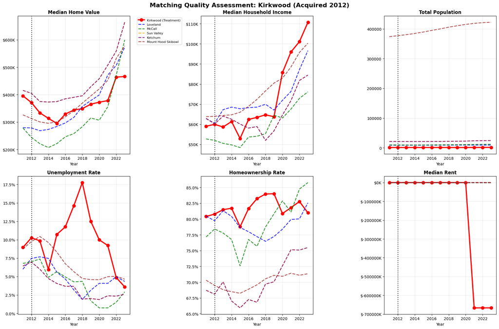

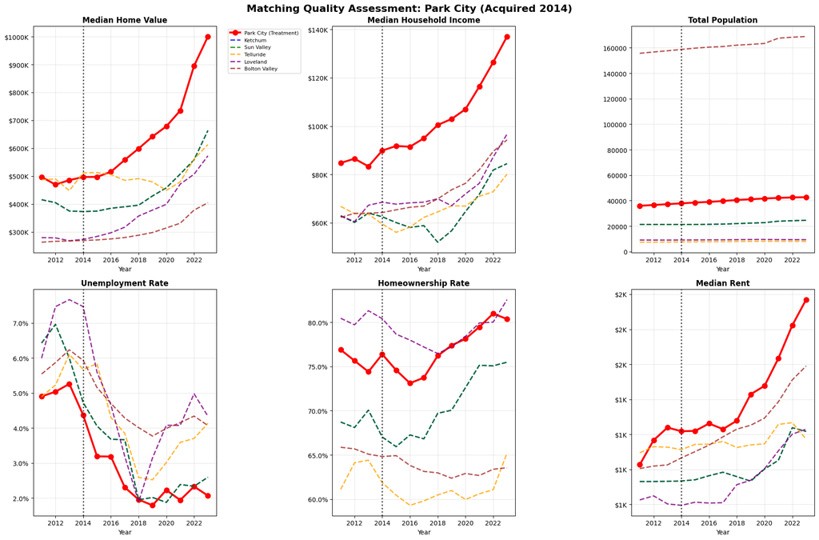

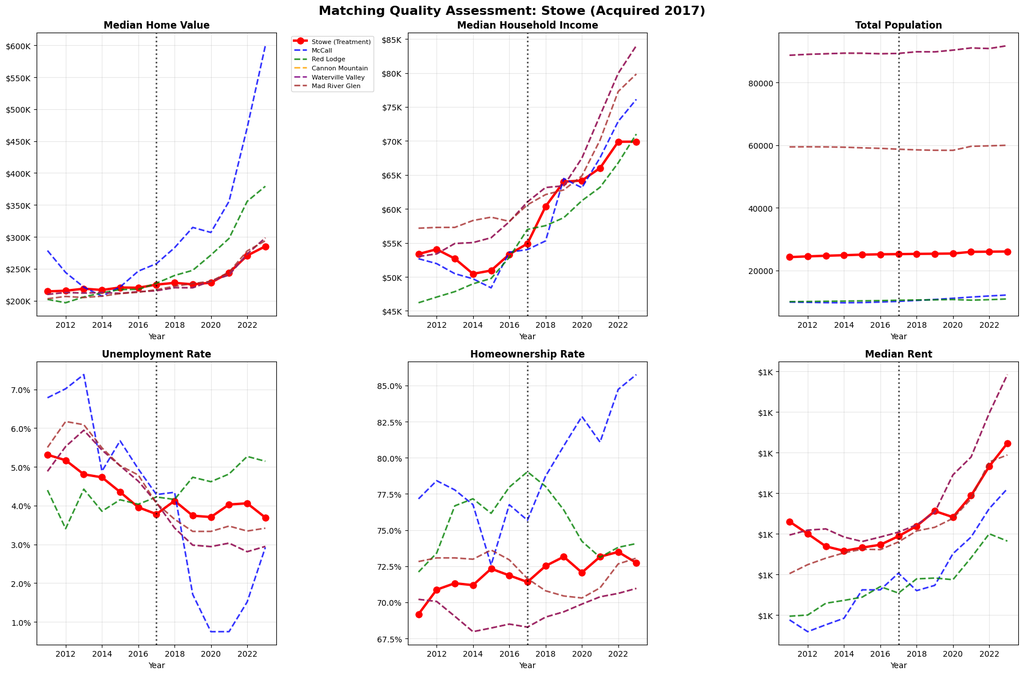

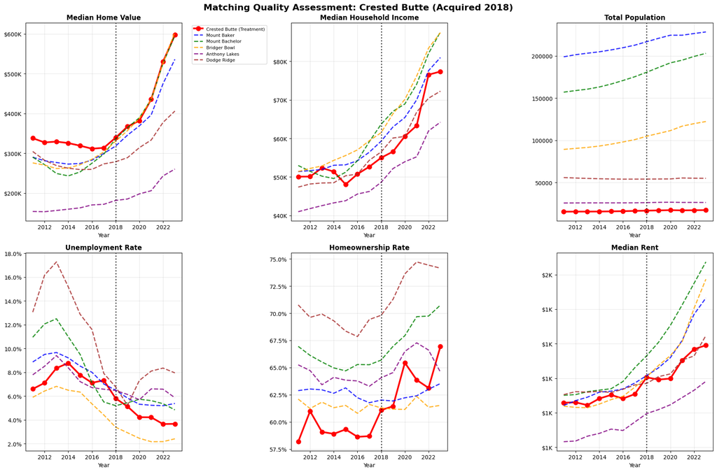

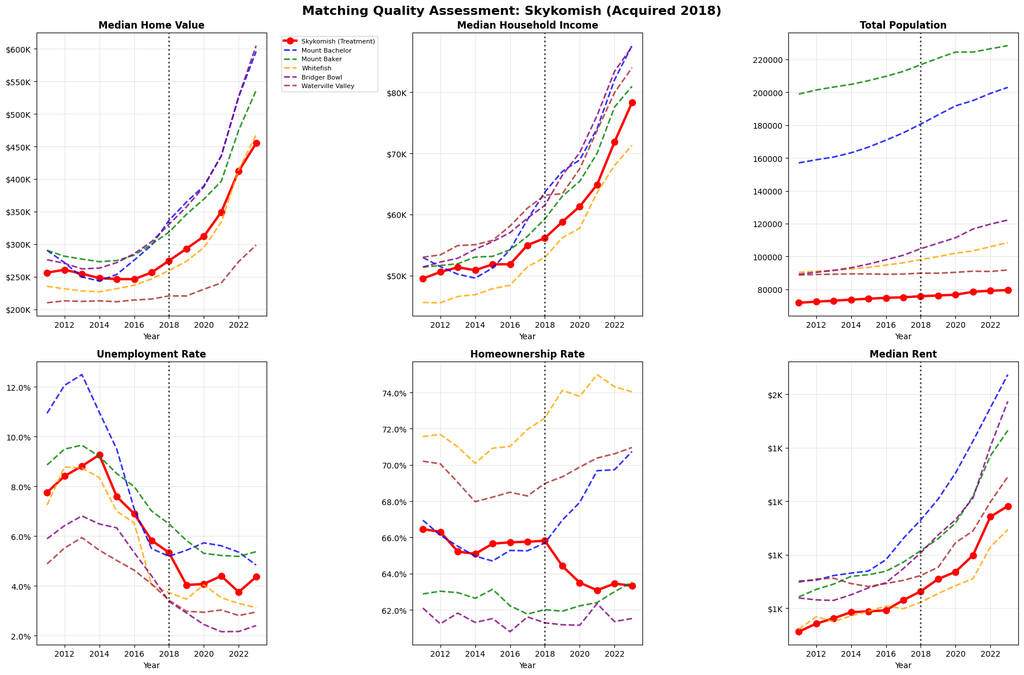

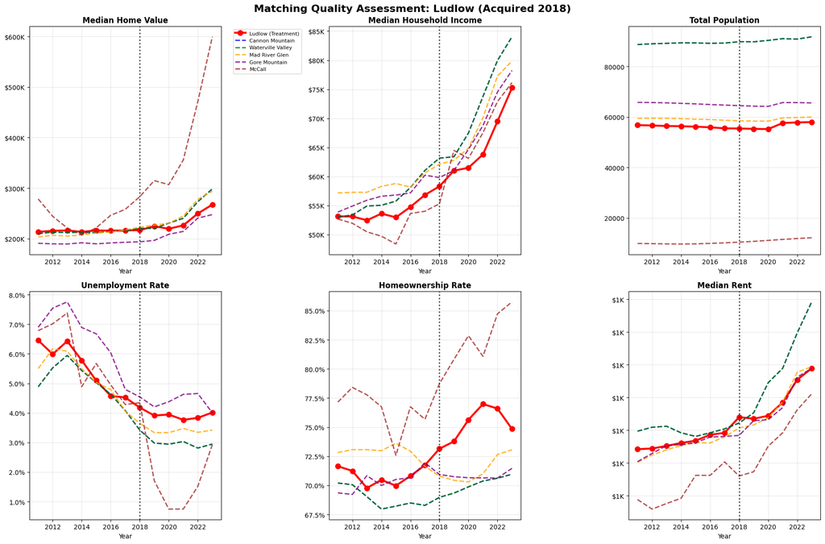

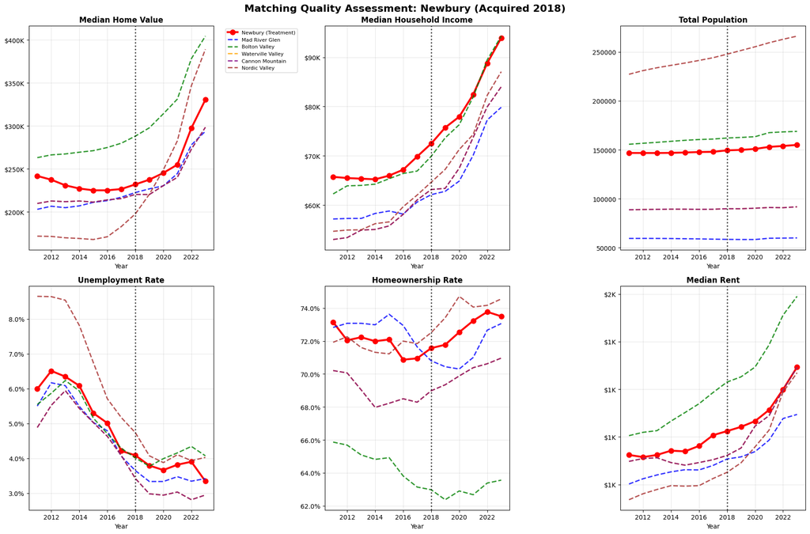

```python
# Generate plots for each treatment town
for treatment_town, info in best_control_matches.items():
    if info['best_controls']:
        create_matching_plots(treatment_town, info['best_controls'], info['acquisition_year'])
```

```python
# Create comprehensive summary
summary_data = []
for treatment_town, info in best_control_matches.items():
    summary_data.append({
        'Treatment_Town': treatment_town,
        'Resort': info['resort'],
        'Acquisition_Year': info['acquisition_year'],
        'Best_Control_1': info['best_controls'][0] if len(info['best_controls']) > 0 else 'N/A',
        'Best_Control_2': info['best_controls'][1] if len(info['best_controls']) > 1 else 'N/A',
        'Best_Control_3': info['best_controls'][2] if len(info['best_controls']) > 2 else 'N/A',
        'Best_Control_4': info['best_controls'][3] if len(info['best_controls']) > 3 else 'N/A',
        'Best_Control_5': info['best_controls'][4] if len(info['best_controls']) > 4 else 'N/A',
    })

summary_df = pd.DataFrame(summary_data)

# Show a nice printout of the summary for the best controls
print("\n" + "="*80)
print("ENHANCED VAIL CAUSAL INFERENCE - POST-2011 ACQUISITIONS")
print("="*80)
print(summary_df.to_string(index=False))
```

```
================================================================================
ENHANCED VAIL CAUSAL INFERENCE - POST-2011 ACQUISITIONS
================================================================================
Treatment_Town                        Resort  Acquisition_Year  Best_Control_1    Best_Control_2    Best_Control_3    Best_Control_4     Best_Control_5
      Kirkwood      Kirkwood Mountain Resort              2012        Loveland            McCall        Sun Valley           Ketchum Mount Hood Skibowl
     Park City     Park City Mountain Resort              2014         Ketchum        Sun Valley         Telluride          Loveland      Bolton Valley
         Stowe         Stowe Mountain Resort              2017          McCall         Red Lodge   Cannon Mountain Waterville Valley     Mad River Glen
 Crested Butte Crested Butte Mountain Resort              2018     Mount Baker    Mount Bachelor      Bridger Bowl     Anthony Lakes        Dodge Ridge
     Skykomish                  Stevens Pass              2018  Mount Bachelor       Mount Baker         Whitefish      Bridger Bowl  Waterville Valley
        Ludlow         Okemo Mountain Resort              2018 Cannon Mountain Waterville Valley    Mad River Glen     Gore Mountain             McCall
       Newbury          Mount Sunapee Resort              2018  Mad River Glen     Bolton Valley Waterville Valley   Cannon Mountain      Nordic Valley
```

### Step 6: Apply difference-in-differences method

```python
# We need some more imports for the next steps
from sklearn.linear_model import LinearRegression
from scipy import stats
import statsmodels.api as sm
import statsmodels.formula.api as smf
from statsmodels.stats.diagnostic import het_white
from statsmodels.stats.stattools import durbin_watson
```

#### This 'create_did_dataset' function below builds a Difference-in-Differences dataset by filtering the treatment town and its matched controls, creating treatment and post-acquisition indicators (plus interaction terms), adding relative event years, and preparing log-transformed outcome variables for analysis.

```python
# Create Difference-in-Differences dataset function
def create_did_dataset(treatment_town, control_towns, acquisition_year):
    # Filter data for treatment and matched controls
    did_data = all_data[
        ((all_data['town'] == treatment_town) & (all_data['resort_type'] == 'treatment')) |
        ((all_data['town'].isin(control_towns)) & (all_data['resort_type'] == 'control'))
    ].copy()

    # Create DiD variables
    did_data['treated'] = (did_data['town'] == treatment_town).astype(int)
    did_data['post'] = (did_data['year'] >= acquisition_year).astype(int)
    did_data['treated_post'] = did_data['treated'] * did_data['post']

    # Add relative year (for event study)
    did_data['years_from_acquisition'] = did_data['year'] - acquisition_year

    # Clean and prepare outcome variables
    outcome_vars = ['median_home_value', 'median_household_income', 'median_rent',
                   'unemployment_rate', 'homeownership_rate', 'total_population']

    # Log transform for percentage interpretation (except rates)
    for var in ['median_home_value', 'median_household_income', 'median_rent', 'total_population']:
        if var in did_data.columns:
            did_data[f'log_{var}'] = np.log(did_data[var].replace(0, np.nan))

    return did_data

# Test with first treatment town
test_town = list(best_control_matches.keys())[0]
test_controls = best_control_matches[test_town]['best_controls']
test_year = best_control_matches[test_town]['acquisition_year']

sample_did = create_did_dataset(test_town, test_controls, test_year)
print(f"Sample DiD dataset created for {test_town}: {sample_did.shape}")
print(f"Variables: {sample_did.columns.tolist()}")
```

[output not shown]

#### This 'estimate_did_effects' function estimates Difference-in-Differences treatment effects for multiple outcomes by running fixed-effects regressions with robust standard errors, extracting effect sizes, confidence intervals, significance levels, and summarizing the results.

```python
# Difference-in-Differences estimation function
def estimate_did_effects(treatment_town, control_towns, acquisition_year, outcome_vars=None):
    if outcome_vars is None:
        outcome_vars = ['log_median_home_value', 'log_median_household_income', 'log_median_rent',
                       'unemployment_rate', 'homeownership_rate', 'log_total_population']

    # Create dataset
    did_data = create_did_dataset(treatment_town, control_towns, acquisition_year)

    results = {}

    print(f"\n{'='*60}")
    print(f"DiD ANALYSIS: {treatment_town} (Acquired {acquisition_year})")
    print(f"Controls: {', '.join(control_towns[:3])}{'...' if len(control_towns) > 3 else ''}")
    print(f"{'='*60}")

    for outcome in outcome_vars:
        if outcome not in did_data.columns or did_data[outcome].isna().all():
            print(f"⚠️  {outcome}: No data available")
            continue

        # Drop missing values for this outcome
        analysis_data = did_data.dropna(subset=[outcome])

        if len(analysis_data) < 10:  # Need minimum observations
            print(f"⚠️  {outcome}: Insufficient data ({len(analysis_data)} obs)")
            continue

        try:
            # Run DiD regression with fixed effects
            formula = f"{outcome} ~ treated + post + treated_post + C(year) + C(town)"
            model = smf.ols(formula, data=analysis_data).fit(cov_type='HC3')  # Robust SE

            # Extract treatment effect
            treatment_effect = model.params['treated_post']
            std_error = model.bse['treated_post']
            p_value = model.pvalues['treated_post']
            conf_int = model.conf_int().loc['treated_post']

            # Calculate percentage effect for log variables
            if outcome.startswith('log_'):
                pct_effect = (np.exp(treatment_effect) - 1) * 100
                pct_ci_low = (np.exp(conf_int[0]) - 1) * 100
                pct_ci_high = (np.exp(conf_int[1]) - 1) * 100
                effect_str = f"{pct_effect:+6.1f}%"
                ci_str = f"[{pct_ci_low:+.1f}%, {pct_ci_high:+.1f}%]"
            else:
                effect_str = f"{treatment_effect:+8.3f}"
                ci_str = f"[{conf_int[0]:+.3f}, {conf_int[1]:+.3f}]"

            # Significance stars
            stars = "***" if p_value < 0.01 else "**" if p_value < 0.05 else "*" if p_value < 0.1 else ""

            print(f"{outcome.replace('log_', '').replace('_', ' ').title():<25} | "
                  f"Effect: {effect_str} {stars:<3} | "
                  f"95% CI: {ci_str} | "
                  f"p: {p_value:.3f}")

            results[outcome] = {
                'treatment_effect': treatment_effect,
                'std_error': std_error,
                'p_value': p_value,
                'conf_int': conf_int.tolist(),
                'n_obs': len(analysis_data),
                'r_squared': model.rsquared,
                'model': model
            }

        except Exception as e:
            print(f"⚠️  {outcome}: Estimation failed ({str(e)[:50]}...)")

    print(f"\n{'*' if any(r['p_value'] < 0.1 for r in results.values()) else ''}p<0.1, **p<0.05, ***p<0.01")

    return results
```

```python
# Run the DiD analysis for all treatment towns
all_did_results = {}

print("RUNNING DIFFERENCE-IN-DIFFERENCES ANALYSIS")
print("="*80)

for treatment_town, info in best_control_matches.items():
    if info['best_controls']:
        try:
            results = estimate_did_effects(
                treatment_town,
                info['best_controls'],
                info['acquisition_year']
            )
            all_did_results[treatment_town] = results
        except Exception as e:
            print(f"Failed analysis for {treatment_town}: {e}")

print(f"\n✅ Completed DiD analysis for {len(all_did_results)} towns")
```

```
RUNNING DIFFERENCE-IN-DIFFERENCES ANALYSIS
================================================================================

============================================================
DiD ANALYSIS: Kirkwood (Acquired 2012)
Controls: Loveland, McCall, Sun Valley...
============================================================
Median Home Value         | Effect:  -17.7%     | 95% CI: [-100.0%, +298759251324967411056088009588114712915083264.0%] | p: 0.997
Median Household Income   | Effect:  +10.4%     | 95% CI: [-100.0%, +62162135177091150324822988161300824064.0%] | p: 0.998
Median Rent               | Effect:   -7.5%     | 95% CI: [-84.1%, +436.5%] | p: 0.930
Unemployment Rate         | Effect:   +3.541     | 95% CI: [-35.761, +42.843] | p: 0.860
Homeownership Rate        | Effect:   +0.700     | 95% CI: [-532.415, +533.815] | p: 0.998
Total Population          | Effect:   +1.0%     | 95% CI: [-100.0%, +444235675148936311548817862295552.0%] | p: 1.000

p<0.1, **p<0.05, ***p<0.01

============================================================
DiD ANALYSIS: Park City (Acquired 2014)
Controls: Ketchum, Sun Valley, Telluride...
============================================================
Median Home Value         | Effect:  +14.6% *** | 95% CI: [+4.0%, +26.3%] | p: 0.006
Median Household Income   | Effect:  +14.4% *** | 95% CI: [+6.1%, +23.4%] | p: 0.000
Median Rent               | Effect:  +11.9%     | 95% CI: [-3.0%, +29.1%] | p: 0.122
Unemployment Rate         | Effect:   +0.009     | 95% CI: [-0.710, +0.727] | p: 0.981
Homeownership Rate        | Effect:   +1.954     | 95% CI: [-1.011, +4.920] | p: 0.196
Total Population          | Effect:   +5.6% *** | 95% CI: [+3.0%, +8.3%] | p: 0.000

*p<0.1, **p<0.05, ***p<0.01

============================================================
DiD ANALYSIS: Stowe (Acquired 2017)
Controls: McCall, Red Lodge, Cannon Mountain...
============================================================
Median Home Value         | Effect:  -11.1% *** | 95% CI: [-18.1%, -3.4%] | p: 0.005
Median Household Income   | Effect:   -2.3%     | 95% CI: [-7.6%, +3.3%] | p: 0.408
Median Rent               | Effect:   -4.6% *   | 95% CI: [-9.5%, +0.6%] | p: 0.081
Unemployment Rate         | Effect:   +1.005 *** | 95% CI: [+0.244, +1.767] | p: 0.010
Homeownership Rate        | Effect:   +0.593     | 95% CI: [-1.150, +2.335] | p: 0.505
Total Population          | Effect:   -0.5%     | 95% CI: [-2.6%, +1.7%] | p: 0.672

```

[output cut: 40 more lines]

```

============================================================
DiD ANALYSIS: Newbury (Acquired 2018)
Controls: Mad River Glen, Bolton Valley, Waterville Valley...
============================================================
Median Home Value         | Effect:   -8.6% *** | 95% CI: [-13.9%, -3.0%] | p: 0.003
Median Household Income   | Effect:   -2.4% *   | 95% CI: [-4.9%, +0.2%] | p: 0.074
Median Rent               | Effect:   -3.3% *   | 95% CI: [-7.0%, +0.5%] | p: 0.089
Unemployment Rate         | Effect:   +0.234     | 95% CI: [-0.099, +0.567] | p: 0.168
Homeownership Rate        | Effect:   +0.600     | 95% CI: [-0.181, +1.381] | p: 0.132
Total Population          | Effect:   +0.1%     | 95% CI: [-1.1%, +1.3%] | p: 0.882

*p<0.1, **p<0.05, ***p<0.01

✅ Completed DiD analysis for 7 towns
```